# Powerlifter EDA

smd

2026-06-07

# Motivation

I was reading Scale by Geoffrey West and there was a bit in there talking about how strength scales with size. The underlying theory is this: Think of a cube. If you double the length of the edge, the cross-sectional area of the cube increases by a factor of 4 (= 2^2) and the volume of the cube increases by a factor of eight (=2^3). If you think of something like a 2x4 used in construction, its ability to support a load is largely driven by its cross-sectional area. You can think of volume as a proxy for weight (= volume * density). The theory is the relationship between strength and weight is as follows:

$$\text{Strength} = a \cdot \text{Body
Weight}^{2/3}$$
where $a$ is some constant. There is an 1956 article in Science by M.H. Lietzke (https://www.science.org/doi/10.1126/science.124.3220.486) which assesses this relationship using world record weight-lifting totals and finds good agreement with the theory. I don’t have access to the full article because it is behind a paywall but from the first page preview, I know the exponent on body weight was found to be 0.6748 which is very close to the expected 0.66 repeating.

I am curious to see if I can recreated this on a larger more modern dataset.

# Setup

I found the following dataset on Kaggle:

https://www.kaggle.com/datasets/open-powerlifting/powerlifting-database?resource=download&select=openpowerlifting-2024-01-06-4c732975.csv.

It is very large (a couple of millions of rows) and so I chose to restrict my analysis to male lifters, who used the minimum in equipment aids (“raw” lifts), did all three lift types (squat, bench press and deadlift) and were “tested” for what I assume are performance enhancing drugs. This filtering was done with the script filtering_raw_data.R and then imported here. I also decided to restrict my analysis to lifters who competed from 2000 and onwards.

```r
setwd("~/GitHub/powerlifting_eda")
library(tidyverse)
library(scales)
library(broom)

df <- read_csv("lifters.zip")
# some additional cleaning is required required
lifters <- df %>%
  # filter(!is.na(date)) %>%

  mutate(year = year(date)) %>%
  filter(year >= 2000) %>%
  mutate(half_decade = (year %/% 5) * 5) %>%
  mutate(decade = (year %/% 10) * 10) %>%
  filter(!is.na(age)) %>%
  filter(!is.na(bodyweight_kg)) %>%
  filter(age >= 18) %>%

  # while total_kg is already provided, I am doing an explicit calculation here to be certain
  filter(best3squat_kg > 0) %>%
  filter(best3bench_kg > 0) %>%
  filter(best3deadlift_kg > 0) %>%
  mutate(total_kg = best3squat_kg + best3bench_kg + best3deadlift_kg) %>%
  filter(!is.na(total_kg))
```

# Preliminary EDA

As this dataset spans multiple decades, its best to first see if some of the variables I might want to control for in the model change with time.

## Number of observations

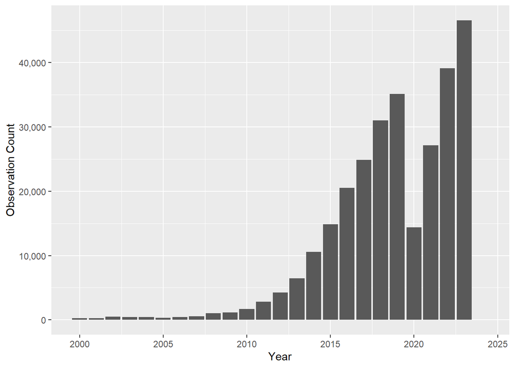

```r
lifters %>%
  ggplot(aes(year)) +
  geom_bar() +
  scale_y_continuous(labels = label_comma()) +
  labs(
    x = "Year",
    y = "Observation Count"
  )
```

Maybe powerlifting has become more popular or maybe the results from competitions just more likely to be included in the dataset as time progresses.

## Have lifters become stronger?

Like with the Lietzke article, I will use the total weight lifted since this will help to eliminate the effect of lifters who are better at some lifts over others.

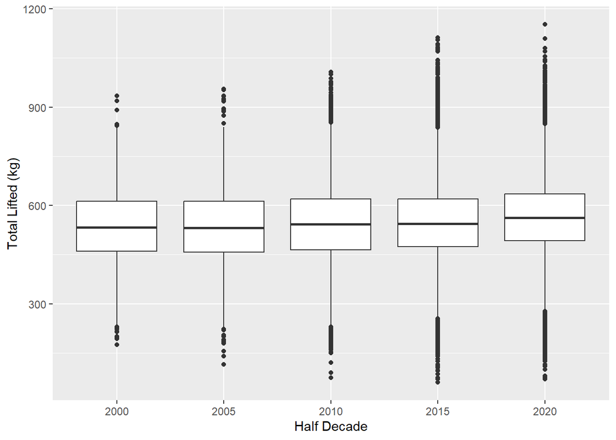

```r
lifters %>%
  ggplot(aes(as_factor(half_decade), total_kg)) +
  geom_boxplot() +
  labs(
    x = "Half Decade",
    y = "Total Lifted (kg)"
  )
```

There looks to be a slow climb in the median over time as well an increase in the frequency of outliers.

Lets confirm the increase in total lift weight using regression

```r
tidy(lm(total_kg ~ year, data = lifters))
```

```
## # A tibble: 2 × 5
##   term        estimate std.error statistic   p.value
##   <chr>          <dbl>     <dbl>     <dbl>     <dbl>
## 1 (Intercept) -3954.    115.         -34.3 1.85e-257
## 2 year            2.23    0.0571      39.1 0
```

# Have lifters become heavier with time?

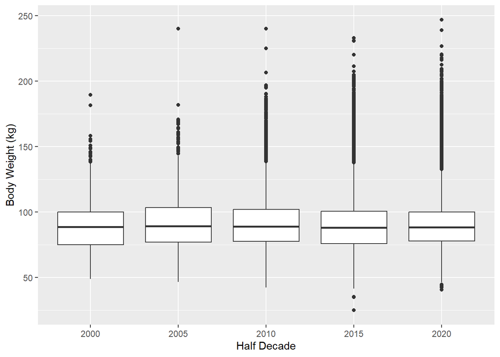

```r
lifters %>%
  ggplot(aes(as_factor(half_decade), bodyweight_kg)) +
  geom_boxplot() +
  labs(
    x = "Half Decade",
    y = "Body Weight (kg)"
  )
```

It looks quite flat to me. Some of the top end outliers are a little concerning. While it is still possible, a 200+ kg (440+ lb) lifter seems unlikely. There may be some data quality issues.

Again, I will run a regression to check my hunch.

```r
tidy(lm(bodyweight_kg ~ year, data = lifters))
```

```
## # A tibble: 2 × 5
##   term        estimate std.error statistic  p.value
##   <chr>          <dbl>     <dbl>     <dbl>    <dbl>
## 1 (Intercept) 191.      19.7          9.67 3.93e-22
## 2 year         -0.0498   0.00977     -5.10 3.35e- 7
```

The slope is looks to be statistically significant but very small and negative meaning that lifters are getting slightly lighter with time.

# How does age impact the amount you can lift?

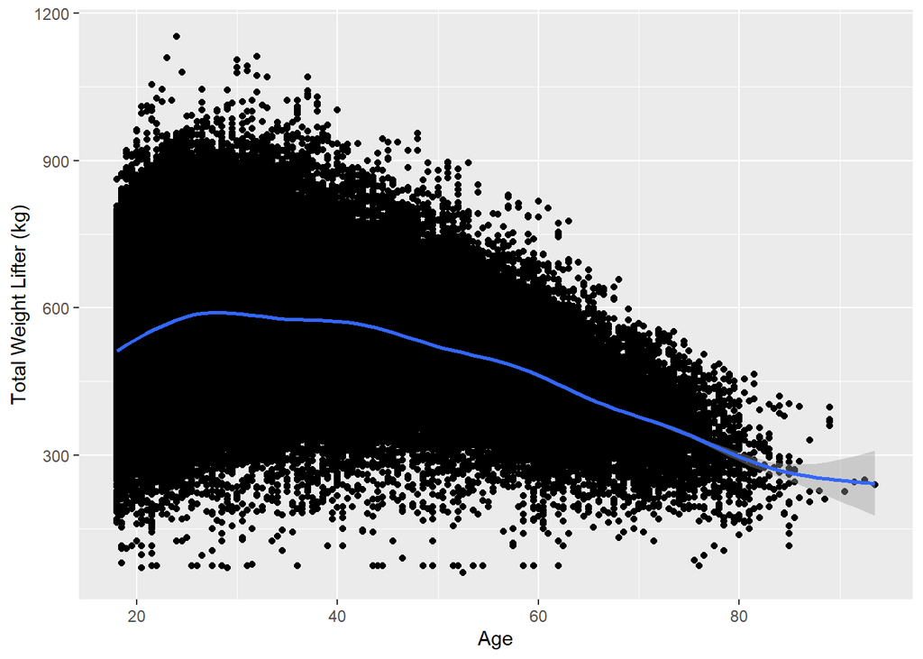

```r
lifters %>%
  ggplot(aes(age, total_kg)) +
  geom_point() +
  geom_smooth() +
  labs(
    x = "Age",
    y = "Total Weight Lifter (kg)"
  )
```

# Modelling

Given what I learned in the preliminary EDA section, I think I am in a good position to build a model. I’ll do a linear regression with log10(total weight lifted) as the response variable and log10(body weight in kg) as the explanatory variable. The slope between these two variables equals the exponent term of the model presented in the Motivation section. I will also include linear terms in age and year as well as a quadratic term in age in an effort to try and control for these variables.

```r
model1_data <- lifters %>%
  select(
    total_kg,
    bodyweight_kg,
    age,
    year
  ) %>%
  mutate(log_total_kg = log10(total_kg)) %>%
  mutate(log_bodyweight_kg = log10(bodyweight_kg)) %>%
  mutate(age_squared = age * age)

tidy(lm(log_total_kg ~ log_bodyweight_kg + age_squared + age + year, model1_data))
```

```
## # A tibble: 5 × 5
##   term               estimate   std.error statistic  p.value
##   <chr>                 <dbl>       <dbl>     <dbl>    <dbl>
## 1 (Intercept)       -1.42     0.0753          -18.9 1.04e-79
## 2 log_bodyweight_kg  0.548    0.00158         347.  0
## 3 age_squared       -0.000108 0.000000766    -141.  0
## 4 age                0.00645  0.0000612       105.  0
## 5 year               0.00149  0.0000373        40.0 0
```

Taking an alpha of 5%, we see that all terms in the model are statistically significant. The slope associated with the log10(bodyweight) is 0.548 (0.001). This is less than the theoretical 0.66 repeating and the 0.675 measured by Lietzke in 1956. Maybe my controls are working that well. To test this, I’ll fit another model where I will control for year and age directly through filtering. I will only consider lifters between the ages of 20 and 30 and I will only use competitions from 2023 (n = 27020).

```r
model2_data <- model1_data %>%
  filter(between(age, 20, 30)) %>%
  filter(year == 2023)

tidy(lm(log_total_kg ~ log_bodyweight_kg, model2_data))
```

```
## # A tibble: 2 × 5
##   term              estimate std.error statistic p.value
##   <chr>                <dbl>     <dbl>     <dbl>   <dbl>
## 1 (Intercept)          1.76    0.00988      178.       0
## 2 log_bodyweight_kg    0.515   0.00508      101.       0
```

I find a value of 0.515 (0.005) for the exponent which is even further from my original estimate. It follows that I will stay with my original estimate of 0.548 (0.001) for the exponent value.